# Лабораторная работа

Анализ файловой системы Linux. Команды для работы с файлами и каталогами

Дудырев Г. А.

Российский университет дружбы народов, Москва, Россия

11 марта 2023

## Цель

Ознакомление с файловой системой Linux, её структурой, именами и содержанием каталогов. Приобретение практических навыков по применению команд для работы с файлами и каталогами, по управлению процессами (и работами), по проверке исполь- зования диска и обслуживанию файловой системы.

## Ход выполнения

Первым делом в ходе лабораторной работы, мы научились создавать файлы, а также копировать, перемещать и переименовывать файлы и каталоги.

## Ход выполнения

Для создания файла используется команда touch. Для копирования команда cp, если нам надо скопировать каталог, то используем опцию -r

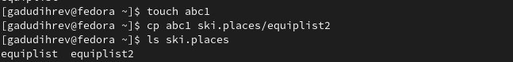

## Ход выполнения

Для перемещения и изменения имени используется команда mv

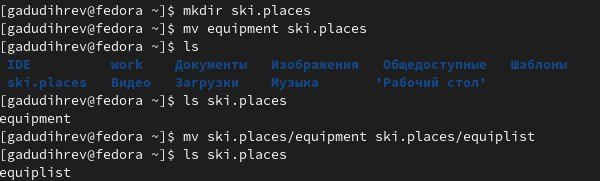

## Ход выполнения

Также мы познакомились с тем, как можно изменять права доступа. У любого объекта есть тип ‘-’ - это файл, ‘d’ - каталог. ‘r’ - права чтения, ‘w’ - права записи, ‘x’ - права выполнения, а также группы пользователей ugo - владелец, члены группы владельца и другие пользователи. Мы смогли поработать с изменением прав доступа, используя команду chmod

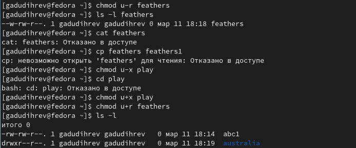

Права доступа

## Ход выполнения

В конце было необходимо с помощью команды man просмотреть команды mount, fsck, mkfs, kill

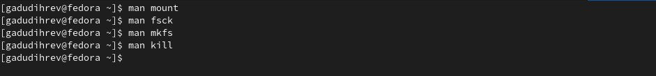

Просмотр команд

## Выводы

Были получены навыки работы с файловой системой Linux, её структурой, именами и содержанием каталогов. Приобретены практические навыки по применению команд для работы с файлами и каталогами, по управлению процессами (и работами), по проверке исполь- зования диска и обслуживанию файловой системы.